# Recap of class 4

- Recap of class 4 topics
- Class 4 homework review

# Analysis Reproducibility and Literate Programming Concepts

The gold standard of analysis validation is *replication*. This is often not possible or practical due to time, cost, opportunity, ethical, data access, or other constraints. As such, we typicaly try to make analyses which can’t be replicated *reproducible*, meaning another analyst or researcher can review and validate every step you took to come up with your conclusion. This is incredibly useful for documenting, sharing, and double-checking work.

Literate programming is the concept of mixing a natural language (i.e. English) and a computer language (i.e. R) in order to explain analyses more easily. This is a great way to create reproducible data analyses, since you can have your entire code available with natural language instructions. The technique can also be used to create readable technical or non-technical documents that double up as reproducible data analyses. R Markdown is a R tool used to create documents with the concept of literate programming in mind.

# R Markdown

R Markdown is built-in with R Studio. It is similar to a R script, but you can specify where code chunks begin and end. You can also add images, hyperlinks, and other such objects to your document. A quick document with formatting guidelines can be found [here](http://rmarkdown.rstudio.com/authoring_basics.html).

When creating your document, always keep in mind which code chunks should be executed, or even shown. One great feature of R Markdown is that the code needs to run in order to successfully print (knit), thus demanding a minimum level of quality.

A good R Markdown document should: - Start with “raw data” - whatever this might mean in your context; importantly, it should not include data that was manipulated by hand without documentation - Try to do everything in code vs. point-and-click user interfaces; this forces you to document your work clearly because a computer can *only* do what you instruct it to - Use version control and commenting - Document your software and hardware environment, or default preferences, if being shared to a wide enough audience that this becomes relevant

To know if you clearly documented your entire analysis and made it reproducible, ask yourself: How far back can a reader go until the analysis is no longer reproducible? The answer to this question should be all the way to extracting raw data from its repository.

# Machine Learning Demo

Note: Machine learning should be an entire class on its own. This demo is intended to show the power of R with a simulated real-world scenario while students are becoming comfortable with the language. This demo does not include enough information for a student to pick up on machine learning skills on its own. The demo is placed in this class because it’s a shorter one.

## Predict Ship Acution Prices

Will use the following libraries: - **tidyverse** for data manipulation - **caret** for machine learning - **yarrr** for datasets - **GGally** for a plot matrix

Note: Help with the caret package can be found [here](http://topepo.github.io/caret/pre-processing.html).

```r
# Load required libraries
library(tidyverse)
library(yarrr)
library(caret)
library(GGally)
# Set seed for reproducibility
set.seed(78345)
```

Explore and clean data to be predicted: The yarrr::auction data.frame.

```r
# Copy data.frame go Global.Env(), create an index, and make condition/color/style variables into factors
df <- auction %>%
  mutate(condition = as.factor(condition)) %>%
  mutate(color = as.factor(color)) %>%
  mutate(style = as.factor(style))

# Explore data and visualize
str(df)
```

```
## 'data.frame':    1000 obs. of  8 variables:
##  $ cannons  : num  18 21 20 24 20 21 18 23 17 19 ...
##  $ rooms    : num  20 21 18 20 21 19 17 20 14 14 ...
##  $ age      : num  140 93 48 81 93 60 107 83 67 104 ...
##  $ condition: Factor w/ 9 levels "1","2","3","4",..: 5 5 2 5 2 6 5 5 7 3 ...
##  $ color    : Factor w/ 5 levels "black","brown",..: 4 4 3 5 4 4 1 2 1 5 ...
##  $ style    : Factor w/ 2 levels "classic","modern": 1 2 1 1 2 1 1 2 1 2 ...
##  $ jbb      : num  3976 3463 3175 4463 2858 ...
##  $ price    : num  3502 2955 3281 4400 2177 ...
```

```r
summary(df)
```

```
##     cannons          rooms            age           condition
##  Min.   : 7.00   Min.   : 4.00   Min.   :  4.00   4      :223
##  1st Qu.:17.00   1st Qu.:13.00   1st Qu.: 79.00   5      :213
##  Median :20.00   Median :16.00   Median :100.00   6      :189
##  Mean   :20.07   Mean   :16.03   Mean   : 99.54   7      :132
##  3rd Qu.:23.00   3rd Qu.:19.00   3rd Qu.:120.00   3      :115
##  Max.   :33.00   Max.   :29.00   Max.   :198.00   2      : 55
##                                                   (Other): 73
##     color         style          jbb           price
##  black :293   classic:500   Min.   :1556   Min.   : 990
##  brown :304   modern :500   1st Qu.:3032   1st Qu.:2922
##  plum  : 49                 Median :3426   Median :3391
##  red   :212                 Mean   :3418   Mean   :3372
##  salmon:142                 3rd Qu.:3808   3rd Qu.:3832
##                             Max.   :5043   Max.   :5018
##
```

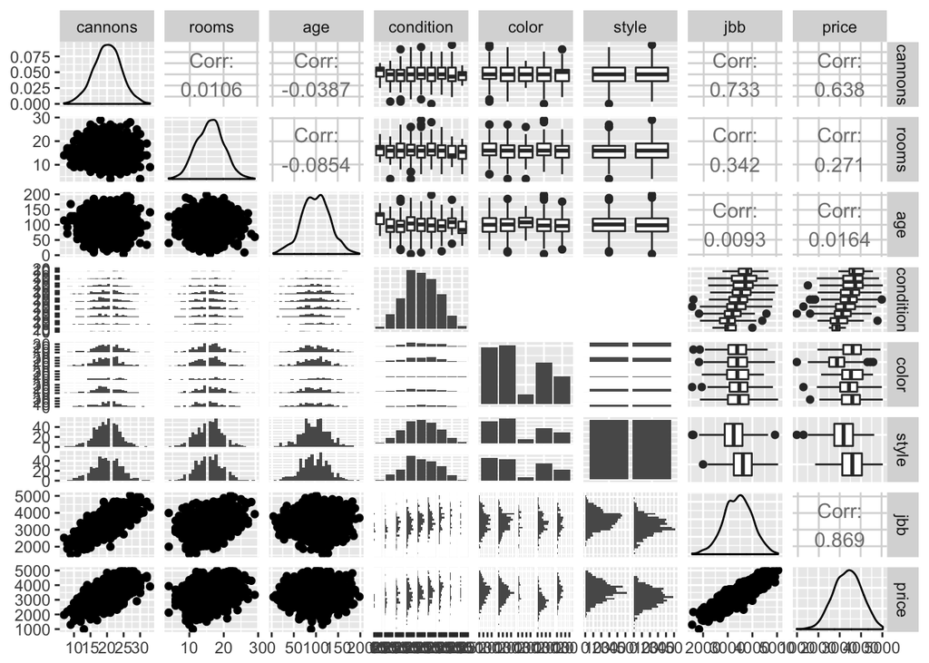

```r
df %>%
  ggpairs()
```

First, we’ll assess the performance of Jack’s Blue Book (JBB) as a predictor.

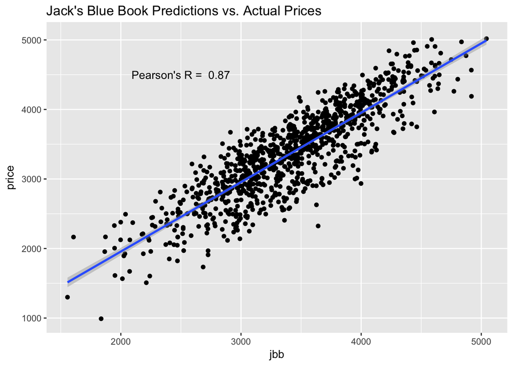

```r
ggplot(data = df, aes(x = jbb, y = price)) +
  geom_point() +
  geom_smooth(method = "lm") +
  ggtitle("Jack's Blue Book Predictions vs. Actual Prices") +
  annotate("text", x = 2500, y = 4500, label = paste("Pearson's R = ", round(
    cor(
      select(df, jbb),
      select(df, price)
      ),
    2)
    )
  )
```

Seems like it is a good predictor, with correlation to actual prices of approximately 0.87. We’ll aim on creating a model which competes with this predictor. First, we’ll create a validation dataset so that we can compare final performanceagainst JBB.

```r
# Create test and training partitions
index_test <- df %>%
  select(price) %>%
  unlist() %>%
  createDataPartition(p = .35, list = FALSE)

df_test <- df %>%
  slice(index_test)

df_training <- df %>%
  slice(-index_test)

# Create validation partition from test
index_validation <- df_test %>%
  select(price) %>%
  unlist() %>%
  createDataPartition(p = .05, list = FALSE)

df_validation <- df_test %>%
  slice(index_validation)

df_test <- df_test %>%
  slice(-index_validation)

# Cleanup environment
rm(df, index_test, index_validation)
```

Check for columns in the training set that should not be used.

```r
# Check for near zero variance variables
df_training %>%
  select(-jbb) %>%
  nzv() # None
```

```
## integer(0)
```

```r
# Check for highly correlated variables
corr_matrix <- df_training %>%
  select(-color, -style, -condition, -jbb) %>%
  cor()

findCorrelation(corr_matrix) # None
```

```
## integer(0)
```

```r
# Check for linear dependencies
df_training %>%
  select(-style, -color, -condition, -jbb) %>%
  findLinearCombos() # None
```

```
## $linearCombos
## list()
##
## $remove
## NULL
```

```r
# Remove jbb variable from training data prior to training models
df_training <- df_training %>%
  select(-jbb)

# Clean environment
rm(corr_matrix)
```

Train models. We will use 10 k-fold cross validation to estimate in-sample performance and pre-process the data during training so that it is centered and scaled.

```r
# Train models: Random forest
model_rf <- train(price ~ .,
                  data = df_training,
                  method = "rf",
                  trControl = trainControl(method = "cv", number = 10),
                  preProc = c("center", "scale"))
# Train models: Generalized linear model
model_glm <- train(price ~ .,
                  data = df_training,
                  method = "glm",
                  trControl = trainControl(method = "cv", number = 10),
                  preProc = c("center", "scale"))

# Train models: K nearest neighbors
model_knn <- train(price ~ .,
                  data = df_training,
                  method = "knn",
                  trControl = trainControl(method = "cv", number = 10),
                  preProc = c("center", "scale"))

# Train models: Partial least squares
model_pls <- train(price ~ .,
                  data = df_training,
                  method = "pls",
                  trControl = trainControl(method = "cv", number = 10),
                  preProc = c("center", "scale"))
```

Now we review our models and evaluate in-sample performance.

```r
model_rf
```

```
## Random Forest
##
## 648 samples
##   6 predictor
##
## Pre-processing: centered (16), scaled (16)
## Resampling: Cross-Validated (10 fold)
## Summary of sample sizes: 583, 583, 583, 584, 584, 582, ...
## Resampling results across tuning parameters:
##
##   mtry  RMSE      Rsquared
##    2    415.7389  0.7334848
##    9    334.0097  0.7427551
##   16    340.4415  0.7304841
##
## RMSE was used to select the optimal model using  the smallest value.
## The final value used for the model was mtry = 9.
```

```r
model_glm
```

```
## Generalized Linear Model
##
## 648 samples
##   6 predictor
##
## Pre-processing: centered (16), scaled (16)
## Resampling: Cross-Validated (10 fold)
## Summary of sample sizes: 583, 584, 583, 583, 582, 584, ...
## Resampling results:
##
##   RMSE      Rsquared
##   282.8554  0.8135736
```

```r
model_knn
```

```
## k-Nearest Neighbors
##
## 648 samples
##   6 predictor
##
## Pre-processing: centered (16), scaled (16)
## Resampling: Cross-Validated (10 fold)
## Summary of sample sizes: 583, 583, 584, 583, 582, 584, ...
## Resampling results across tuning parameters:
##
##   k  RMSE      Rsquared
##   5  433.0685  0.5647028
##   7  427.3699  0.5836676
##   9  432.2391  0.5792399
##
## RMSE was used to select the optimal model using  the smallest value.
## The final value used for the model was k = 7.
```

```r
model_pls
```

```
## Partial Least Squares
##
## 648 samples
##   6 predictor
##
## Pre-processing: centered (16), scaled (16)
## Resampling: Cross-Validated (10 fold)
## Summary of sample sizes: 583, 582, 582, 584, 584, 583, ...
## Resampling results across tuning parameters:
##
##   ncomp  RMSE      Rsquared
##   1      315.2651  0.7630891
##   2      288.1301  0.8034004
##   3      285.3587  0.8071544
##
## RMSE was used to select the optimal model using  the smallest value.
## The final value used for the model was ncomp = 3.
```

For in-sample performance, the generalized linear model has the lowest root mean sauqred error (RMSE). This means it is the best predicting model based on in-sample performance. We can also, plot residuals for this model to check if there is any pattern left to be discovered.

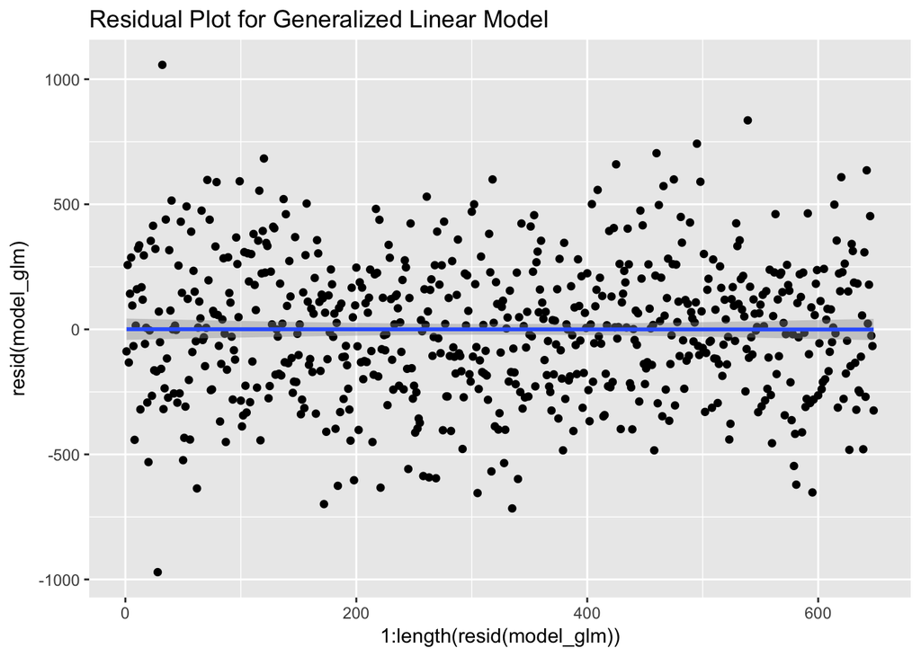

```r
# Residual plot
ggplot(mapping = aes(x = 1:length(resid(model_glm)), y = resid(model_glm), geom = "point")) +
  geom_point() +
  geom_smooth(method = "lm") +
  ggtitle("Residual Plot for Generalized Linear Model")
```

```r
# Source of multiplot function: http://www.cookbook-r.com/Graphs/Multiple_graphs_on_one_page_(ggplot2)/

# Multiple plot function
#
# ggplot objects can be passed in ..., or to plotlist (as a list of ggplot objects)
# - cols:   Number of columns in layout
# - layout: A matrix specifying the layout. If present, 'cols' is ignored.
#
# If the layout is something like matrix(c(1,2,3,3), nrow=2, byrow=TRUE),
# then plot 1 will go in the upper left, 2 will go in the upper right, and
# 3 will go all the way across the bottom.
#
multiplot <- function(..., plotlist=NULL, file, cols=1, layout=NULL) {
  library(grid)

  # Make a list from the ... arguments and plotlist
  plots <- c(list(...), plotlist)

  numPlots = length(plots)

  # If layout is NULL, then use 'cols' to determine layout
  if (is.null(layout)) {
    # Make the panel
    # ncol: Number of columns of plots
    # nrow: Number of rows needed, calculated from # of cols
    layout <- matrix(seq(1, cols * ceiling(numPlots/cols)),
                    ncol = cols, nrow = ceiling(numPlots/cols))
  }

 if (numPlots==1) {
    print(plots[[1]])

  } else {
    # Set up the page
    grid.newpage()
    pushViewport(viewport(layout = grid.layout(nrow(layout), ncol(layout))))

    # Make each plot, in the correct location
    for (i in 1:numPlots) {
      # Get the i,j matrix positions of the regions that contain this subplot
      matchidx <- as.data.frame(which(layout == i, arr.ind = TRUE))

      print(plots[[i]], vp = viewport(layout.pos.row = matchidx$row,
                                      layout.pos.col = matchidx$col))
    }
  }
}
```

```r
# Predict with four models
pred_test_rf <- predict(model_rf, newdata = df_test)
pred_test_glm <- predict(model_glm, newdata = df_test)
pred_test_knn <- predict(model_knn, newdata = df_test)
pred_test_pls <- predict(model_pls, newdata = df_test)

# Check performance numerically
results_test <- df_test %>%
  select(price) %>%
  unlist()

# Use postResample function to calculate regression performane, then combine all in one data.frame and print
as.data.frame(
  rbind(
    c("rf", postResample(pred = pred_test_rf, obs = results_test)),
    c("glm", postResample(pred = pred_test_glm, obs = results_test)),
    c("knn", postResample(pred = pred_test_knn, obs = results_test)),
    c("pls", postResample(pred = pred_test_pls, obs = results_test))
  )
)
```

```
##    V1             RMSE          Rsquared
## 1  rf 332.284908712113  0.74728889937787
## 2 glm 293.334042779813 0.799031263228156
## 3 knn 457.390104828041  0.51714457112676
## 4 pls 297.934184252377 0.792673503219268
```

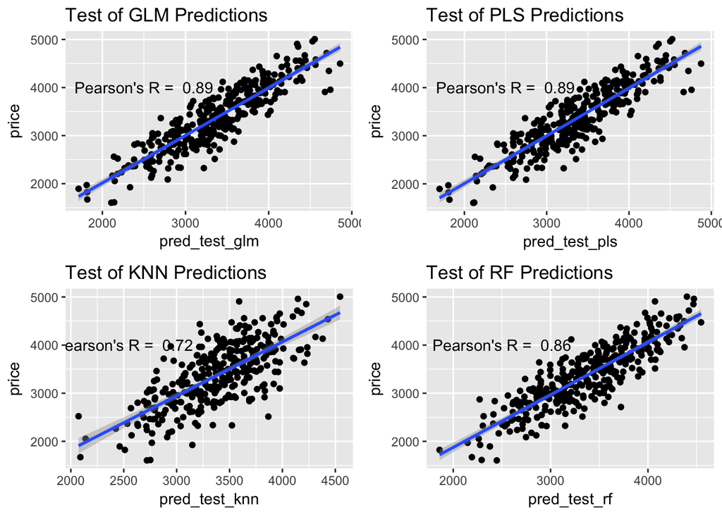

```r
# Add predictions to test data.frame
df_test_results <- cbind(df_test,
                         pred_test_glm,
                         pred_test_knn,
                         pred_test_pls,
                         pred_test_rf)

# Create scatter plots
plot_test_glm <- ggplot(data = df_test_results, aes(x = pred_test_glm, y = price)) +
  geom_point() +
  geom_smooth(method = "lm") +
  ggtitle("Test of GLM Predictions") +
  annotate("text", x = 2500, y = 4000, label = paste("Pearson's R = ", round(
    cor(
      select(df_test_results, pred_test_glm),
      select(df_test_results, price)
      ),
    2)
    )
  )

plot_test_rf <- ggplot(data = df_test_results, aes(x = pred_test_rf, y = price)) +
  geom_point() +
  geom_smooth(method = "lm") +
  ggtitle("Test of RF Predictions") +
  annotate("text", x = 2500, y = 4000, label = paste("Pearson's R = ", round(
    cor(
      select(df_test_results, pred_test_rf),
      select(df_test_results, price)
      ),
    2)
    )
  )

plot_test_pls <- ggplot(data = df_test_results, aes(x = pred_test_pls, y = price)) +
  geom_point() +
  geom_smooth(method = "lm") +
  ggtitle("Test of PLS Predictions") +
  annotate("text", x = 2500, y = 4000, label = paste("Pearson's R = ", round(
    cor(
      select(df_test_results, pred_test_pls),
      select(df_test_results, price)
      ),
    2)
    )
  )

plot_test_knn <- ggplot(data = df_test_results, aes(x = pred_test_knn, y = price)) +
  geom_point() +
  geom_smooth(method = "lm") +
  ggtitle("Test of KNN Predictions") +
  annotate("text", x = 2500, y = 4000, label = paste("Pearson's R = ", round(
    cor(
      select(df_test_results, pred_test_knn),
      select(df_test_results, price)
      ),
    2)
    )
  )

# Plot using multiplot function
multiplot(plot_test_glm, plot_test_knn, plot_test_pls, plot_test_rf, cols = 2)
```

The generalized linear model continues to have the lowest RMSE and best performance out-of-sample. We will use it as our predictor.

```r
# Cleanup environment
rm(pred_test_rf, pred_test_knn, pred_test_pls, pred_test_glm,
   plot_test_glm, plot_test_rf, plot_test_knn, plot_test_pls,
   results_test, df_test, df_test_results,
   model_pls, model_rf, model_knn, df_training)
```

Predict values and compare to JBB.

```r
# Predict
pred_validation <- predict(model_glm, newdata = df_validation)

# Results data.frame
df_validation <- df_validation %>%
  mutate(prediction = pred_validation) %>%
  select(price, jbb, prediction)

# Differences
df_validation <- df_validation %>%
  mutate(jbb_diff = abs(jbb - price)) %>%
  mutate(prediction_diff = abs(prediction - price))

# Final account
df_validation %>%
  select(jbb_diff) %>%
  drop_na() %>%
  sum() # Could also use mean()
```

```
## [1] 5340
```

```r
df_validation %>%
  select(prediction_diff) %>%
  drop_na() %>%
  sum() # Could also use mean()
```

```
## [1] 5153.015
```

```r
# Cleanup environment
rm(multiplot, pred_validation)
rm(df_validation, model_glm)
```

Great success!

## Switching Gears: Check for Normality of Data

Just for kicks, let’s try some normality tests to see if we can perform a T-Test to compare ship prices based on style. First, we’ll view the two distributions as density plots:

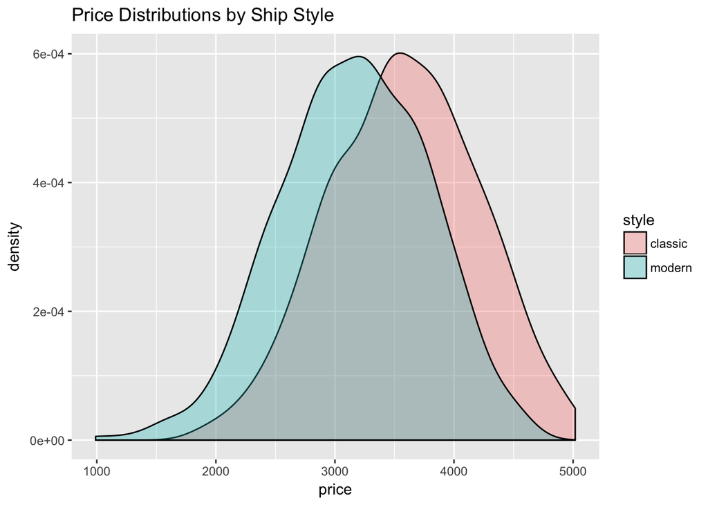

```r
# Copy data.frame go Global.Env(), create an index, and make condition/color/style variables into factors
df <- auction %>%
  mutate(style = as.factor(style)) %>%
  select(price, style) %>%
  drop_na()

# Visualize
ggplot(data = df, aes(x = price, fill = style)) +
  geom_density(alpha = .3) +
  ggtitle("Price Distributions by Ship Style")
```

The distributions look normal, but is there a plot dedicated for this? Of course!

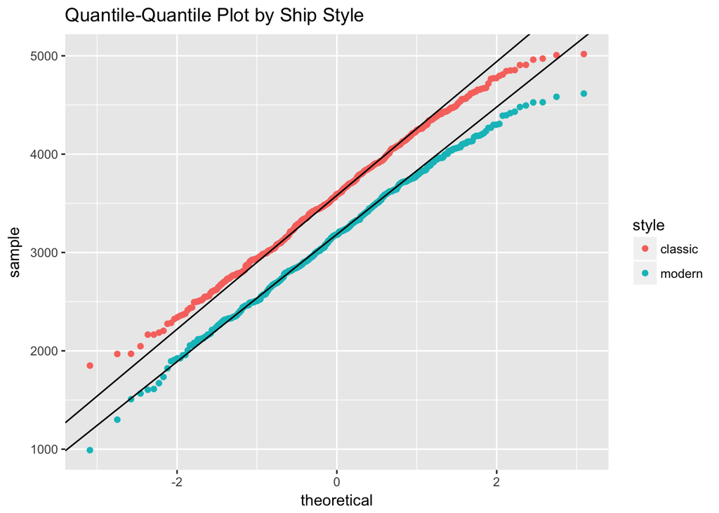

```r
# Get classic and modern prices as vectors
price_classic <- df %>%
  filter(style == "classic") %>%
  select(price) %>%
  unlist()

price_modern <- df %>%
  filter(style == "modern") %>%
  select(price) %>%
  unlist()

# Formulas to calculate theoretical quantiles
# Inspired from stats::qqline()
# Is a numeric vector
qq_abline_slope <- function(x) {
  x <- x[!is.na(x)]
  slope <- diff(quantile(x, c(0.25, 0.75))) / diff(qnorm(c(0.25, 0.75)))
  return(slope)
}

qq_abline_intersect <- function(x, slope = NULL) {
  # If slope is not provided, use qq_abline_slope() to calculate it
    if (is.null(slope)) {
    slope <- qq_abline_slope(x)
  }

  x <- x[!is.na(x)]
  intersect <- quantile(x, 0.25) - slope * qnorm(0.25)
  return(intersect)
}

# Calculate theorecial quantiles
slope_classic <- qq_abline_slope(price_classic)
int_classic <- qq_abline_intersect(price_classic)

slope_modern <- qq_abline_slope(price_modern)
int_modern <- qq_abline_intersect(price_modern)

# Plot
ggplot(data = df, aes(sample = price, color = style)) +
  geom_qq() +
  ggtitle("Quantile-Quantile Plot by Ship Style") +
  geom_abline(slope = slope_classic, intercept = int_classic) +
  geom_abline(slope = slope_modern, intercept = int_modern)
```

```r
# Cleanup Environment
rm(classic_price, int_classic, int_modern,
   slope_classic, slope_modern, x_classic, x_modern, y_classic, y_modern,
   qq_abline_intersect, qq_abline_slope, df)
```

Okay, the data visually appears to be normally distributed - but can we check this with a hypothesis test? Of course!

```r
shapiro.test(price_classic)
```

```
##
##  Shapiro-Wilk normality test
##
## data:  price_classic
## W = 0.99534, p-value = 0.1396
```

```r
shapiro.test(price_modern)
```

```
##
##  Shapiro-Wilk normality test
##
## data:  price_modern
## W = 0.99517, p-value = 0.1213
```

Through all of these methods, we can determine it’s safe to apply a t-test now.

```r
t.test(price_classic, price_modern)
```

```
##
##  Welch Two Sample t-test
##
## data:  price_classic and price_modern
## t = 10.748, df = 997.93, p-value < 2.2e-16
## alternative hypothesis: true difference in means is not equal to 0
## 95 percent confidence interval:
##  343.8613 497.4667
## sample estimates:
## mean of x mean of y
##  3581.838  3161.174
```

```r
# Cleanup Environment
rm(price_classic, price_modern)
```

Nice! We can prove that they have significantly different means.

# Homework

For this class, complete the following homework assignments:

- Review the [R Markdown cheat sheet](https://www.rstudio.com/resources/cheatsheets/) and [R Markdown Reference Guide](https://www.rstudio.com/resources/cheatsheets/)
- Put your capstone analysis in a R Markdown document that uses literate programming to explain the steps you took in your analysis, and your final conclusions
- Practice your analysis skills by answering the following questions using nycflights13 datasets, and document your work using R Markdown:
1. Which NYC airport has the most pronounced seasonal change in flights?
2. What are daily peak times for NYC area airports?
3. Do daily peaks shift over the course of the year or do they remain at the same times?
4. What tail number had the most unique flights in the dataset?
5. What aircraft manufacturer had the most unique flights in the dataset?
6. What is the distibution of flights by aircraft manufacturer?
7. How do aircraft manufacturer cruise speed claims compare to actual airspeeds in flight?
8. Does the duration of cruise have an effect on the relationship above?
9. Is there a relationship between aircraft manufacture date and airspeed?